# Final Project RMD

Marali Benitez, Youcef Djoudi, Kelly Thackery, Samina Issa, Samira Bechi

2025-04-09

```r
##loading in packages and data
library(wooldridge)
library(AER)
library(quantmod)
library(PerformanceAnalytics)
library(lmtest)

#ceosal2 data
ceosalary <- ceosal2

#Murder rates data
data("MurderRates")
mr <- MurderRates
```

#### Data: ceosal2

##### (a) Describe the data. Describe the variables; response, predictors, continuous, categorical variables and missing data.

```r
library(wooldridge)
data("ceosal2")
head(ceosal2)
```

|  | salary | age | college | grad | comten | ceoten | sales | profits | mktval | lsalary | lsales | lmktval | comtensq | ceotensq | profmarg |
| --- | --- | --- | --- | --- | --- | --- | --- | --- | --- | --- | --- | --- | --- | --- | --- |
| 1 | 1161 | 49 | 1 | 1 | 9 | 2 | 6200 | 966 | 23200 | 7.057037 | 8.732305 | 10.051908 | 81 | 4 | 15.580646 |
| 2 | 600 | 43 | 1 | 1 | 10 | 10 | 283 | 48 | 1100 | 6.396930 | 5.645447 | 7.003066 | 100 | 100 | 16.961130 |
| 3 | 379 | 51 | 1 | 1 | 9 | 3 | 169 | 40 | 1100 | 5.937536 | 5.129899 | 7.003066 | 81 | 9 | 23.668638 |
| 4 | 651 | 55 | 1 | 0 | 22 | 22 | 1100 | -54 | 1000 | 6.478509 | 7.003066 | 6.907755 | 484 | 484 | -4.909091 |
| 5 | 497 | 44 | 1 | 1 | 8 | 6 | 351 | 28 | 387 | 6.208590 | 5.860786 | 5.958425 | 64 | 36 | 7.977208 |
| 6 | 1067 | 64 | 1 | 1 | 7 | 7 | 19000 | 614 | 3900 | 6.972606 | 9.852194 | 8.268732 | 49 | 49 | 3.231579 |

**This dataset (`ceosal2`) includes information on CEOs and their companies. The analysis focuses on how various CEO and firm characteristics influence company profits**.

##### Variables:

**Response Variable:** - `profits`: Annual firm profits (in millions).  
- Type: **Continuous**.

| Variable | Description | Type |
| --- | --- | --- |
| `salary` | CEO salary (in thousands) | Continuous |
| `age` | CEO age | Continuous |
| `college` | 1 = undergraduate degree | Categorical (binary) |
| `grad` | 1 = graduate degree | Categorical (binary) |
| `comten` | Years with the company | Continuous |
| `ceoten` | Years as CEO | Continuous |
| `sales` | Company sales (in millions) | Continuous |
| `mktval` | Market value (in millions) | Continuous |
| `lmktval` | Log of market value | Continuous |
| `comtensq` | Square of company tenure | Continuous |
| `ceotensq` | Square of CEO tenure | Continuous |
| `profmarg` | Profit margin = profits/sales | Continuous |

```r
#Check for missing values
colSums(is.na(ceosal2))
```

```
##   salary      age  college     grad   comten   ceoten    sales  profits
##        0        0        0        0        0        0        0        0
##   mktval  lsalary   lsales  lmktval comtensq ceotensq profmarg
##        0        0        0        0        0        0        0
```

**NO missing values in the data set**.

##### (b) Build an optimal model. Print summary: discuss F-test, t-tests, Rsquare, S-square. Take out outliers.

```r
#preliminary model
model <- lm(profits ~ .-lsalary -lmktval -lsales, data=ceosal2)
summary(model)
```

```
##
## Call:
## lm(formula = profits ~ . - lsalary - lmktval - lsales, data = ceosal2)
##
## Residuals:
##     Min      1Q  Median      3Q     Max
## -595.72  -24.52    7.21   37.55  543.72
##
## Coefficients:
##               Estimate Std. Error t value Pr(>|t|)
## (Intercept)  21.725679 119.334493   0.182  0.85576
## salary        0.011629   0.021625   0.538  0.59146
## age          -0.067916   1.592252  -0.043  0.96603
## college     -47.570474  68.855153  -0.691  0.49061
## grad         -1.020730  23.409112  -0.044  0.96527
## comten        1.261179   3.511631   0.359  0.71995
## ceoten       -4.988814   4.417210  -1.129  0.26037
## sales         0.016682   0.002843   5.867 2.36e-08 ***
## mktval        0.044778   0.002732  16.392  < 2e-16 ***
## comtensq     -0.014689   0.077158  -0.190  0.84925
## ceotensq      0.133996   0.147531   0.908  0.36507
## profmarg      1.900953   0.627057   3.032  0.00283 **
## ---
## Signif. codes:  0 '***' 0.001 '**' 0.01 '*' 0.05 '.' 0.1 ' ' 1
##
## Residual standard error: 146.5 on 165 degrees of freedom
## Multiple R-squared:  0.877,  Adjusted R-squared:  0.8688
## F-statistic:   107 on 11 and 165 DF,  p-value: < 2.2e-16
```

**In the primary model, all variables were included except for lsalary, lmktval, and lsales. The R² value is 0.877, indicating that approximately 87.7% of the variation in profits is accounted for by the model. The F-test p-value is less than 2.2e-16, confirming that the model is statistically significant and not due to random chance. Based on the summary output, the predictors that show statistical significance are sales, market value (mktval), and profit margin (profmarg). The residual standard error is 146.5, suggesting that, on average, the model’s profit predictions differ from the actual values by about 146.5 units.**

```r
#taking out outliers
cooksd <- cooks.distance(model)
influential <- as.numeric(names(cooksd)[(cooksd > (4 / nrow(ceosalary)))])
influential
```

```
##  [1]   1  30  34  40  43  44  47  50  52  77  91 101 107 114 135 168
```

```r
newceosalary <- ceosalary[-influential]
#creating reduced model with no outliers in model
newceosalary_model <- lm(profits~.-lsalary -lmktval -lsales, data = newceosalary)
summary(newceosalary_model)
```

```
##
## Call:
## lm(formula = profits ~ . - lsalary - lmktval - lsales, data = newceosalary)
##
## Residuals:
##     Min      1Q  Median      3Q     Max
## -594.21  -25.51    6.62   35.76  553.20
##
## Coefficients:
##               Estimate Std. Error t value Pr(>|t|)
## (Intercept)  27.703509 118.560977   0.234  0.81553
## age          -0.028988   1.587197  -0.018  0.98545
## college     -48.581175  68.681976  -0.707  0.48035
## grad         -1.832048  23.310377  -0.079  0.93745
## comten        1.206672   3.502645   0.345  0.73090
## ceoten       -4.414495   4.276975  -1.032  0.30350
## sales         0.016885   0.002812   6.005 1.17e-08 ***
## mktval        0.045084   0.002666  16.910  < 2e-16 ***
## comtensq     -0.014633   0.076992  -0.190  0.84950
## ceotensq      0.118753   0.144472   0.822  0.41227
## profmarg      1.877254   0.624166   3.008  0.00304 **
## ---
## Signif. codes:  0 '***' 0.001 '**' 0.01 '*' 0.05 '.' 0.1 ' ' 1
##
## Residual standard error: 146.2 on 166 degrees of freedom
## Multiple R-squared:  0.8768, Adjusted R-squared:  0.8694
## F-statistic: 118.1 on 10 and 166 DF,  p-value: < 2.2e-16
```

```r
#creating newer updated model using step function
updatedceosalmodel <- step(newceosalary_model, direction = "both", trace = 0)
summary(updatedceosalmodel)
```

```
##
## Call:
## lm(formula = profits ~ sales + mktval + profmarg, data = newceosalary)
##
## Residuals:
##     Min      1Q  Median      3Q     Max
## -617.41  -23.28    8.08   34.34  553.52
##
## Coefficients:
##               Estimate Std. Error t value Pr(>|t|)
## (Intercept) -26.818425  13.237245  -2.026  0.04430 *
## sales         0.017124   0.002732   6.267 2.83e-09 ***
## mktval        0.045084   0.002588  17.422  < 2e-16 ***
## profmarg      1.852935   0.612487   3.025  0.00286 **
## ---
## Signif. codes:  0 '***' 0.001 '**' 0.01 '*' 0.05 '.' 0.1 ' ' 1
##
## Residual standard error: 144 on 173 degrees of freedom
## Multiple R-squared:  0.8754, Adjusted R-squared:  0.8732
## F-statistic:   405 on 3 and 173 DF,  p-value: < 2.2e-16
```

##### (c) Briefly discuss residuals.

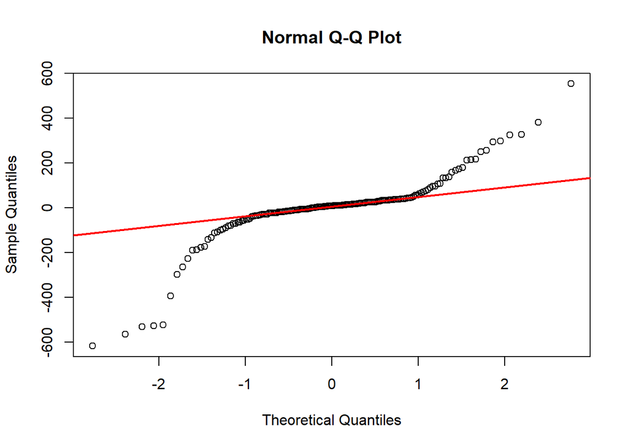

```r
# Q-Q plot: check for normality of residuals
qqnorm(residuals(updatedceosalmodel))
qqline(residuals(updatedceosalmodel), col = "red", lwd = 2)
```

**The normal qqplot deviates quite a bit from the normality line, suggesting that the residuals are not normally distributed**.

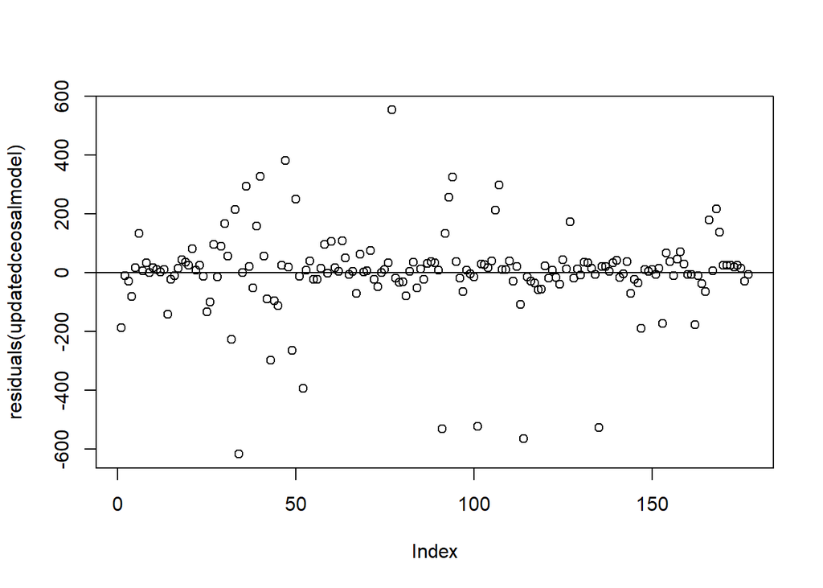

```r
#checking if residuals are randomly distributed
plot(residuals(updatedceosalmodel))
abline(a = 0, b = 0)
```

**The residuals for this model seem to be randomly scattered around 0**.

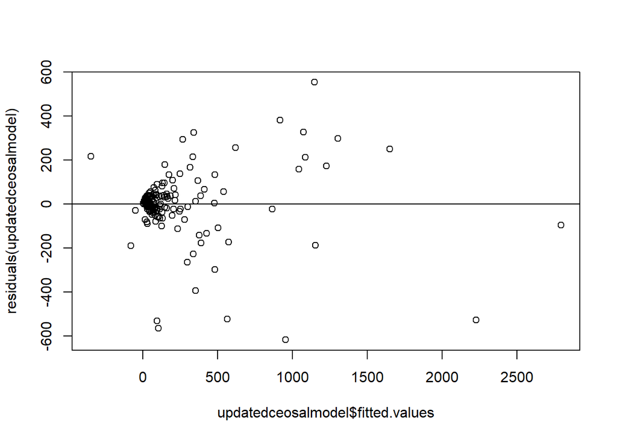

```r
#residuals vs fitted values plot
plot(updatedceosalmodel$fitted.values, residuals(updatedceosalmodel))
abline(a = 0, b = 0)
```

```r
bptest(updatedceosalmodel)
```

```
##
##  studentized Breusch-Pagan test
##
## data:  updatedceosalmodel
## BP = 40.915, df = 3, p-value = 6.818e-09
```

**There does seem to somewhat of a pattern in the residuals vs fitted values plot, suggesting that there is heteroscedasticity present. This is confirmed by the Breusch-Pagan test (which has a p-value of about 6.818e-09), meaning that some predictinos made by the model may not be accurate.**

##### (d) Make 2 predictions with CI’s. Interpret predictions if needed.

```r
# Hypothetical CEO 1
new_ceo1 <- data.frame(
  sales = 4500,
  mktval = 1800,
  profmarg = 10
)

# Hypothetical CEO 2
new_ceo2 <- data.frame(
  sales = 7000,
  mktval = 3000,
  profmarg = 15
)

#make predictions with 95% CI
# Predictions for CEO 1
predict(updatedceosalmodel, newdata = new_ceo1, interval = "confidence")
```

```
##        fit      lwr      upr
## 1 149.9177 123.9457 175.8898
```

```r
# Predictions for CEO 2
predict(updatedceosalmodel, newdata = new_ceo2, interval = "confidence")
```

```
##        fit      lwr      upr
## 1 256.0919 223.5525 288.6312
```

#### Data: MurderRates.

##### (a) Describe the data. Describe the variables; response, predictors, continuous, categorical variables and missing data.

```r
head(mr)
```

|  | rate | convictions | executions | time | income | lfp | noncauc | southern |
| --- | --- | --- | --- | --- | --- | --- | --- | --- |
| 1 | 19.25 | 0.204 | 0.035 | 47 | 1.10 | 51.2 | 0.321 | yes |
| 2 | 7.53 | 0.327 | 0.081 | 58 | 0.92 | 48.5 | 0.224 | yes |
| 3 | 5.66 | 0.401 | 0.012 | 82 | 1.72 | 50.8 | 0.127 | no |
| 4 | 3.21 | 0.318 | 0.070 | 100 | 2.18 | 54.4 | 0.063 | no |
| 5 | 2.80 | 0.350 | 0.062 | 222 | 1.75 | 52.4 | 0.021 | no |
| 6 | 1.41 | 0.283 | 0.100 | 164 | 2.26 | 56.7 | 0.027 | no |

**The murder rates data set contains data collected in 1950 that reflects 44 states’ murder rates among other variables. The variables for this dataset are as follows:**

- rate (continuous): the states murder rate per 100,000 according to the FBI estimate.
- convictions (continuous): the number of convictions divided by the number of murders in 1950.
- executions (continuous): the average number of executions from 1946-1950 divided by the number of convictions in 1950.
- time (discrete): median time (served in months) of convicted murderers in the state released in 1951.
- income (continuous): median family income for the state in 1949 (in thousands of US dollars).
- lfp (continuous): the labor force participation rate in the state in 1949.
- noncaucasian (continous): proportion of the population that is non-cacasian in the state as of 1950.
- southern (factor): indicates if the state is in the south or not.

**There were no missing values in this dataset.**

##### (b) Build an optimal model. Print summary: discuss F-test, t-tests, Rsquare, S-square. Take out outliers**.

```r
#creating preliminary model
murdermodel <- lm(rate~., data = mr)
summary(murdermodel)
```

```
##
## Call:
## lm(formula = rate ~ ., data = mr)
##
## Residuals:
##     Min      1Q  Median      3Q     Max
## -4.9913 -1.1943 -0.3538  1.2383  6.5574
##
## Coefficients:
##             Estimate Std. Error t value Pr(>|t|)
## (Intercept)  0.44436    9.96694   0.045   0.9647
## convictions -4.33938    2.78313  -1.559   0.1277
## executions   2.85276    6.12313   0.466   0.6441
## time        -0.01547    0.00705  -2.194   0.0348 *
## income      -2.50013    1.68519  -1.484   0.1466
## lfp          0.19357    0.20614   0.939   0.3540
## noncauc     10.39903    5.40610   1.924   0.0623 .
## southernyes  3.26216    1.32980   2.453   0.0191 *
## ---
## Signif. codes:  0 '***' 0.001 '**' 0.01 '*' 0.05 '.' 0.1 ' ' 1
##
## Residual standard error: 2.459 on 36 degrees of freedom
## Multiple R-squared:  0.7459, Adjusted R-squared:  0.6965
## F-statistic:  15.1 on 7 and 36 DF,  p-value: 5.105e-09
```

```r
#calculation for preliminary models' s-squared value
#mean(murdermodel$residuals^2)
```

*In the preliminary model, all predictor variables were used to create the model. The R^2 value for this preliminary model is .7459, meaning that 74.59% of the variation in the response can be explained by these predictor variables. The p-value for the f-test in this preliminary model is 5.105e-09, meaning that this model is non trivial. The summary output for the preliminary model also shows that the only statistically significant predictors in this model are time and the southern factor. The S-squared value for this model is about 4.94, meaning that on average, the preliminary model’s predictions deviate by about 4.94 murders from the true murder rate.*

```r
#taking out outliers
cooks <- cooks.distance(murdermodel)
inf <- as.numeric(names(cooks)[cooks>(4/44)])
newmurderdata <- mr[-inf,]

#creating reduced model with no outliers in model
newmurdermodel <- lm(rate~., data = newmurderdata)
summary(newmurdermodel)
```

```
##
## Call:
## lm(formula = rate ~ ., data = newmurderdata)
##
## Residuals:
##     Min      1Q  Median      3Q     Max
## -3.3145 -1.4250  0.0003  1.2285  4.4268
##
## Coefficients:
##              Estimate Std. Error t value Pr(>|t|)
## (Intercept)  3.217234   8.374625   0.384 0.703398
## convictions -6.017805   2.196373  -2.740 0.009966 **
## executions  -4.791480   9.061282  -0.529 0.600603
## time        -0.008623   0.005536  -1.558 0.129156
## income      -2.328506   1.347126  -1.728 0.093538 .
## lfp          0.128752   0.174727   0.737 0.466569
## noncauc      8.937551   4.390175   2.036 0.050119 .
## southernyes  4.379154   1.046576   4.184 0.000208 ***
## ---
## Signif. codes:  0 '***' 0.001 '**' 0.01 '*' 0.05 '.' 0.1 ' ' 1
##
## Residual standard error: 1.841 on 32 degrees of freedom
## Multiple R-squared:  0.8288, Adjusted R-squared:  0.7913
## F-statistic: 22.13 on 7 and 32 DF,  p-value: 1.404e-10
```

```r
#creating newer updated model using step function
updatedmurdermodel <- step(newmurdermodel, direction = "both", trace = 0)
summary(updatedmurdermodel)
```

```
##
## Call:
## lm(formula = rate ~ convictions + time + income + noncauc + southern,
##     data = newmurderdata)
##
## Residuals:
##     Min      1Q  Median      3Q     Max
## -3.6485 -1.2694 -0.0675  1.0782  4.4753
##
## Coefficients:
##              Estimate Std. Error t value Pr(>|t|)
## (Intercept)  9.266257   2.479583   3.737 0.000683 ***
## convictions -6.139134   2.043407  -3.004 0.004969 **
## time        -0.009475   0.005222  -1.814 0.078439 .
## income      -1.919536   1.068678  -1.796 0.081357 .
## noncauc      8.934485   4.095912   2.181 0.036171 *
## southernyes  4.233961   1.012899   4.180 0.000193 ***
## ---
## Signif. codes:  0 '***' 0.001 '**' 0.01 '*' 0.05 '.' 0.1 ' ' 1
##
## Residual standard error: 1.813 on 34 degrees of freedom
## Multiple R-squared:  0.8234, Adjusted R-squared:  0.7974
## F-statistic:  31.7 on 5 and 34 DF,  p-value: 7.059e-12
```

*Removing the outliers took out about 9% of the data. After taking out the outliers, we can see that the R^2 value has increased to .8288, and the the S^2 value has gone down to 1.841. We then reduced the model using the step function, where we can see that the r^2 and s^2 did not change by much (the new r^2 value is .8234 and the new s^2 value is 1.814). The predictors for this model have been reduced to convictions, time, income, noncaucasian, and southern. More of the predictors are statistically significant in this model, with the intercept, convictions, noncaucasian, and southern all being statistically significant according to the p-value found by the t-tests. The f-test for this reduced model shows that it is nontrivial, as the p-value for the f-test is 7.059e-12.*

##### (c) Briefly discuss residuals.

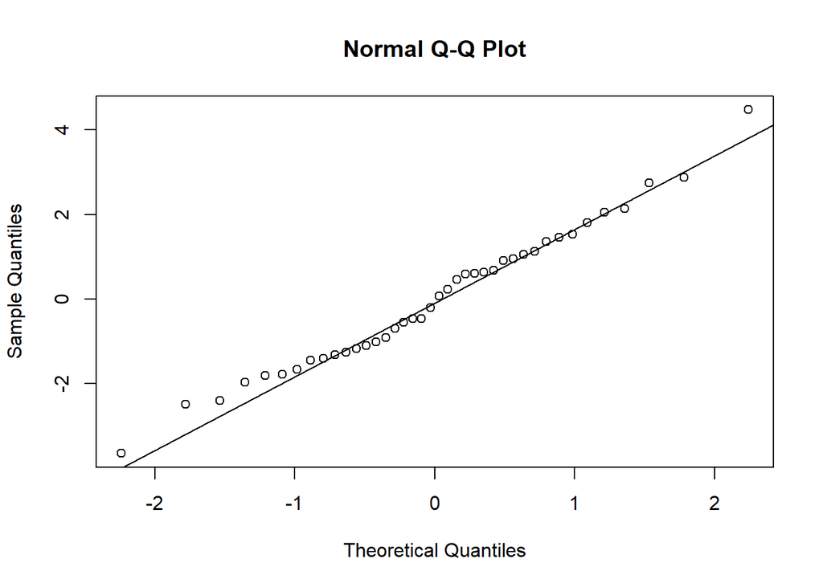

```r
##taking a look at residuals

#checking if data is normally distributed
qqnorm(residuals(updatedmurdermodel))
qqline(residuals(updatedmurdermodel))
```

*The normal qqplot for this model suggests that the residuals in this model are normally distributed*.

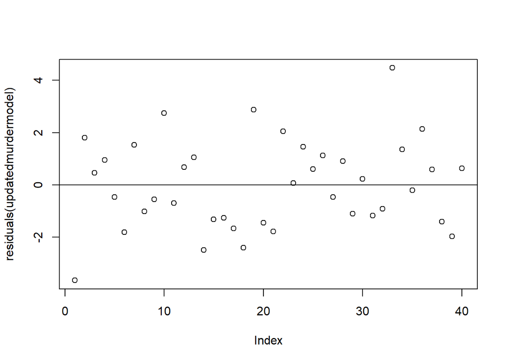

```r
#checking if residuals are randomly distributed
plot(residuals(updatedmurdermodel))
abline(a = 0, b = 0)
```

*The residuals for this model also seem to be randomly scattered around 0, meaning that a linear model may be a good fit for the data*.

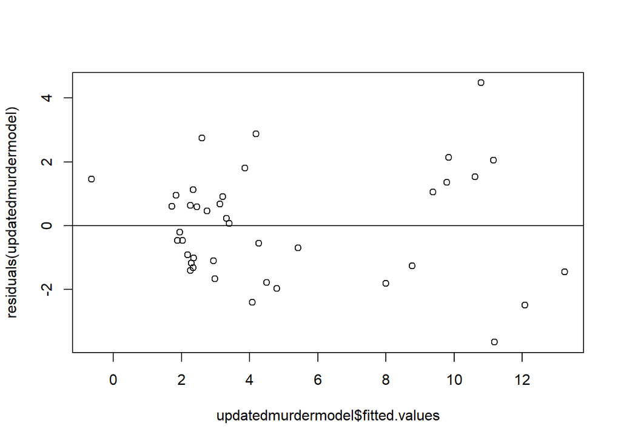

```r
#residuals vs fitted values plot
plot(updatedmurdermodel$fitted.values, residuals(updatedmurdermodel))
abline(a = 0, b = 0)
```

```r
bptest(updatedmurdermodel)
```

```
##
##  studentized Breusch-Pagan test
##
## data:  updatedmurdermodel
## BP = 11.773, df = 5, p-value = 0.03803
```

*In the fitted values vs residuals plot, there does seem to somewhat of a pattern, suggesting that there is heteroscedasticity present. This is confirmed by the Breusch-Pagan test (which has a p-value of about .038)*.

##### (d) Make 2 predictions with CI’s. Interpret predictions if needed.

```r
## hypothetical state 1
state1 <- data.frame(
  convictions = .3,
  time = 150,
  income = 2,
  noncauc = .015,
  southern = "yes"
)

##hypothetical state 2
state2 <- data.frame(
  convictions = .15,
  time =100,
  income = 3,
  noncauc = .2,
  southern = "no"
)

prediction1 <- predict(updatedmurdermodel, newdata = state1, interval = "confidence")
prediction2 <- predict(updatedmurdermodel, newdata = state2, interval = "confidence")

prediction1
```

```
##        fit      lwr      upr
## 1 6.532212 4.461027 8.603398
```

```r
prediction2
```

```
##        fit       lwr      upr
## 1 3.426203 0.4326271 6.419779
```

*Hypothetical state 1 inputs: convictions = .3, time = 150, income = 2, noncaucasian = .015, southern = “yes”. Hypothetical state 2 inputs: convictions = .15, time = 100, income = 3, noncaucasian = .2, southern = “no”. The 95% confidence interval for hypothetical state 1 is (4.46, 8.6), meaning that for a state with those inputs, we are 95% confident that the true murder rate per 100,000 per the FBI estimates for that state is in between those two values. For the 2nd hypothetical state, we would be 95% that the true murder rate per 100,000 per the FBI estimates for that state is in between (.43, 6.42).*

#### Finance Application

##### Read stock prices for 5 different stocks. Close prices for 3 years, most recent 2024. Criteria Beta > 1, PE > 10, growth > 10%, different industries.

```r
# Read stock prices
start<- as.Date("2021-01-01")
end<-as.Date("2024-01-01")
DIS <- getSymbols("DIS", from=start, to=end, auto.assign=FALSE)
NVDA <- getSymbols("NVDA", from=start, to=end, auto.assign=FALSE)
CVNA<-getSymbols("CVNA", from=start, to=end, auto.assign=FALSE)
SPOT<-getSymbols("SPOT", from=start, to=end, auto.assign=FALSE)
DASH<-getSymbols("DASH", from=start, to=end, auto.assign=FALSE)


## Closed price
DIS.close <- DIS[ ,4]
NVDA.close <- NVDA[ ,4]
CVNA.close <- CVNA[ ,4]
SPOT.close <- SPOT[ ,4]
DASH.close <- DASH[ ,4]

## Returns
DIS.return <- dailyReturn(DIS.close)
NVDA.return <- dailyReturn(NVDA.close)
CVNA.return <- dailyReturn(CVNA.close)
SPOT.return <- dailyReturn(SPOT.close)
DASH.return <- dailyReturn(DASH.close)
```

**The stocks selected are: Disney, Nvidia, Carvana, Spotify, and DoorDash. The criteria for selection were: Disney: beta(1.44), P/E(29.69), Growth Estimate(11.28%), Industry: Entertainment Nvidia: beta(1.96), P/E(38.89), Growth Estimate(27.98%), Industry: Semiconductors Carvana: beta(3.62), P/E(138.64), Growth Estimate(43.53%), Industry: Auto & Truck Dealerships Spotify: beta(1.75), P/E(90.03), Growth Estimate(27.20%), Industry: Internet Content & Information DoorDash: beta(1.69), P/E(627.07), Growth Estimate(31.84%), Industry: Communication Services**

##### (a)Plot close prices on three different plots. Notice the general “trend” and “variation” on different spans.

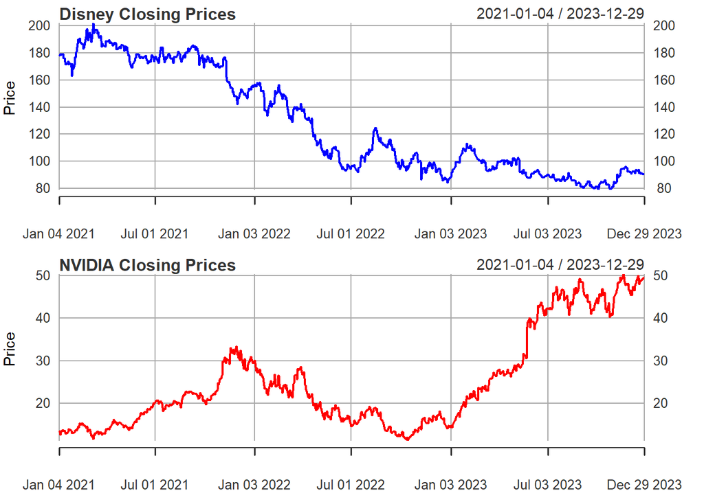

```r
#Plot close stock prices on different plots.
par(mfrow=c(2, 1))
plot(DIS.close, main = "Disney Closing Prices", type = "l", col = "blue", xlab = "Date", ylab = "Price")
plot(NVDA.close, main = "NVIDIA Closing Prices", type = "l", col = "red", xlab = "Date", ylab = "Price")
```

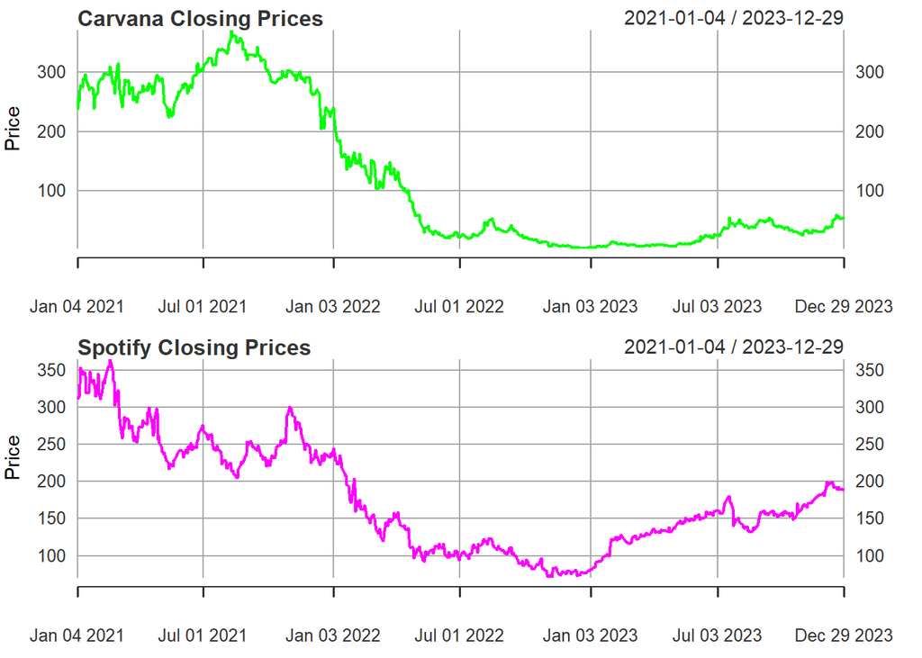

```r
plot(CVNA.close, main = "Carvana Closing Prices", type = "l", col = "green", xlab = "Date", ylab = "Price")
plot(SPOT.close, main = "Spotify Closing Prices", type = "l", col = "magenta", xlab = "Date", ylab = "Price")
```

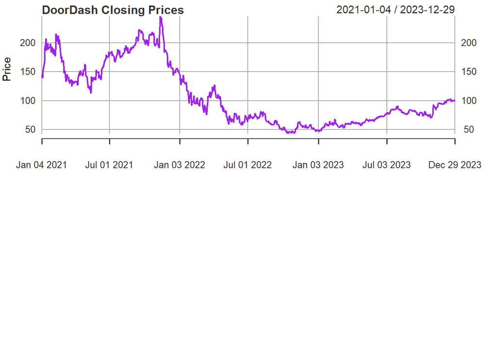

```r
plot(DASH.close, main = "DoorDash Closing Prices", type = "l", col = "purple", xlab = "Date", ylab = "Price")
```

**Remark: The closing prices for Disney, Carvana, Spotify and Doordash show a decline in 2022. Carvana doesn’t have much variation through 2023. Spotify shows an increase with slight variation in 2023. Disney and Doordash both show variation in 2023. The closing price for NVIDIA rises until the end of 2021 then falls until it starts to rise again toward the end of 2022.**

##### (b) Calculate annualized average return and annualized risk.

```r
library(PerformanceAnalytics)
#Calculate the annualized return and annualized risk of each stock.
## A function to compute the Annualized Expected return/Risk
mu.sigma <- function(return){
  mu.ann <- mean(return) * 252
  sigma.ann <- sd(return) * sqrt(252)
  return(c(mu.ann, sigma.ann))
}

## Annualized Expected Return and Annualized Risk
dis <- mu.sigma(DIS.return)
nvda <- mu.sigma(NVDA.return)
cvna <- mu.sigma(CVNA.return)
spot <- mu.sigma(SPOT.return)
dash <- mu.sigma(DASH.return)


cat('Disney:', dis, '\n')
```

```
## Disney: -0.1814154 0.2993281
```

```r
cat('NVIDIA:', nvda, '\n')
```

```
## NVIDIA: 0.5831085 0.5296374
```

```r
cat('Carvana:', cvna, '\n')
```

```
## Carvana: 0.3134923 1.296106
```

```r
cat('Spoify:', spot, '\n')
```

```
## Spoify: -0.03417431 0.5166859
```

```r
cat('DoorDash:', dash, '\n')
```

```
## DoorDash: 0.1089975 0.6705528
```

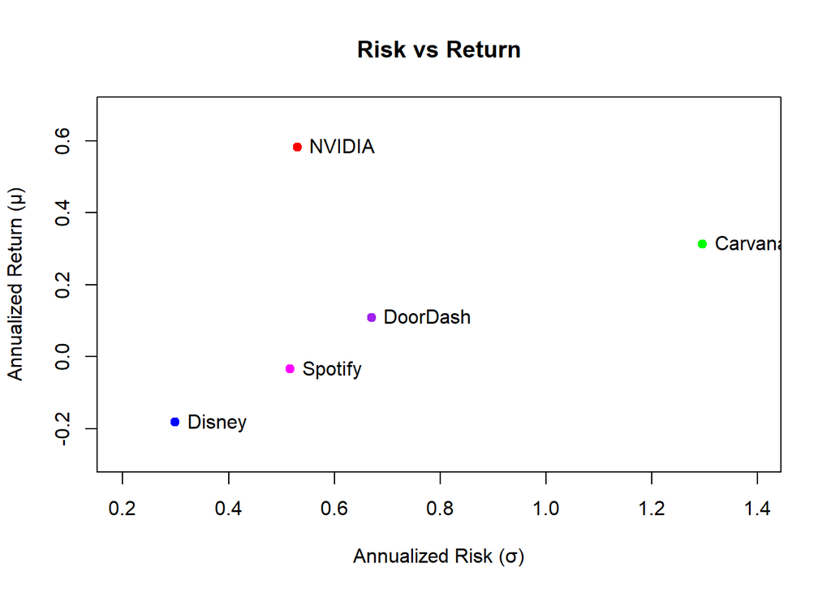

```r
## Plot each stock prices on the same (𝜎−𝜇) planes
risk <- c(dis[2], nvda[2], cvna[2], spot[2], dash[2])
return <- c(dis[1], nvda[1], cvna[1], spot[1], dash[1])
stocks <- c("Disney", "NVIDIA", "Carvana", "Spotify", "DoorDash")

plot(risk, return, main = "Risk vs Return", xlab = "Annualized Risk (σ)", ylab = "Annualized Return (μ)", pch = 19, col = c("blue", "red", "green","magenta","purple"),xlim = c(min(risk) - 0.1, max(risk) + 0.1), ylim = c(min(return) - 0.1, max(return) + 0.1))
points(stocks)
text(risk, return, labels = stocks, pos = 4)
```

##### Present the correlations matrix.

```r
## Correlation Matrix
returns <- cbind(DIS.return,NVDA.return,CVNA.return,SPOT.return,DASH.return)
colnames(returns) <- c('Disney', 'NVIDIA', 'Carvana', 'Spotify','DoorDash')
head(returns)
```

```
##                   Disney       NVIDIA     Carvana      Spotify    DoorDash
## 2021-01-04  0.0000000000  0.000000000  0.00000000  0.000000000  0.00000000
## 2021-01-05  0.0042774077  0.022209954  0.08172852  0.008745985  0.03764631
## 2021-01-06  0.0038107637 -0.058952971 -0.01858518  0.001657494 -0.03060305
## 2021-01-07 -0.0030147013  0.057830260  0.07706415  0.054480638  0.09113642
## 2021-01-08  0.0006159738 -0.005039737  0.03064850  0.065638583  0.02173196
## 2021-01-11  0.0022384794  0.025966476 -0.01547909 -0.025601026  0.06989560
```

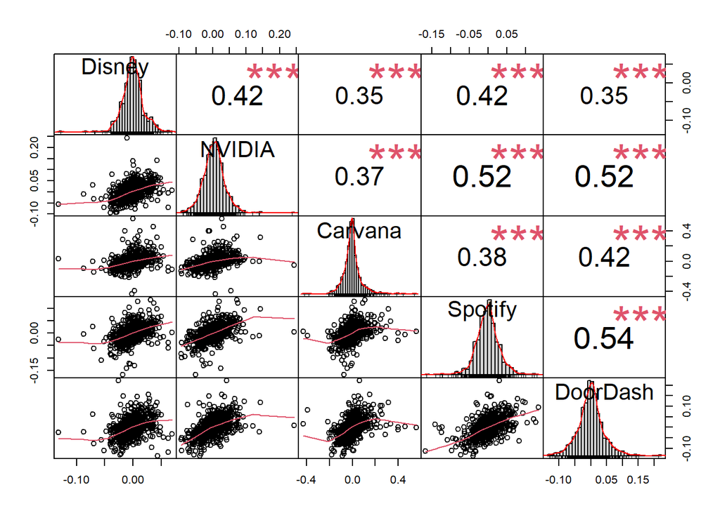

```r
chart.Correlation(returns)
```

##### (c)Plot cumulative returns on one common plot.

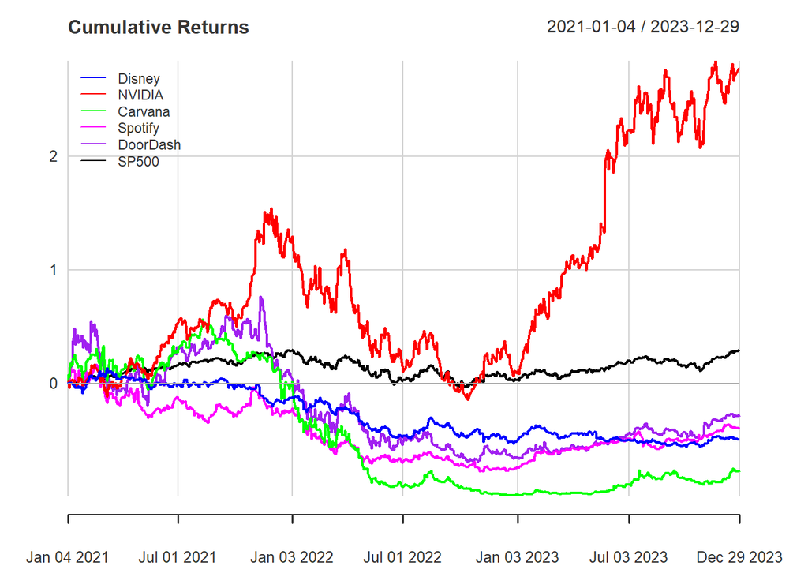

```r
## SP500(Benchmark)
SP500<- getSymbols("^GSPC", from=start, to=end, auto.assign = FALSE)
SP500.close <- SP500[ , 4]
SP500.return<- dailyReturn(SP500.close)
## Combine all returns into one data frame
returns <- cbind(DIS.return, NVDA.return, CVNA.return, SPOT.return, DASH.return, SP500.return)
colnames(returns) <- c('Disney', 'NVIDIA', 'Carvana', 'Spotify', 'DoorDash', 'SP500')


## Plot cumulative returns using chart.CumReturns from PerformanceAnalytics
library(PerformanceAnalytics)
chart.CumReturns(returns, wealth.index = FALSE, legend.loc = 'topleft',
                 main = 'Cumulative Returns', colorset=c('blue','red','green','magenta','purple','black'))
```

**Remark: The SP500 index shows a steady benchmark. The other stocks have varying degrees of performance compared to the SP500. NVIDIA outperformed the SP500, while Disney, Carvana, Spotify, and DoorDash underperformed compared to the SP500.**

##### (d)Estimate alpha, beta, Rsquare.

```r
##Riskfree rates
rf <- read.csv("F-F_Research_Data_Factors_daily.CSV", head=T, skip=3) # a data frame
#head(rf)
rf$dates <- as.Date(rf$X, format="%Y%m%d") # create dates as X in the fama.french
## sort ff according to dates
rf.new <- rf[rf$dates >= "2021-01-01" & rf$dates<= "2024-01-01", ]
#head(rf.new)
rf.new <- rf.new[ -754, ]


# Estimate alpha, beta, Rsquare of 3 stocks.
beta <- function(stock.return, market.return, riskfree.rate) {
    stock.excess <- stock.return - riskfree.rate
    market.excess <- market.return - riskfree.rate
    model <- lm(stock.excess ~ market.excess)
    coefs <- coef(model)
    Rsquare <- summary(model)$r.squared
    results <- data.frame(alpha = coefs[1], beta = coefs[2], Rsquare = Rsquare)
    return(results)
}

# Call beta function for each stock
res_DIS   <- beta(DIS.return, SP500.return, rf.new$RF)
res_NVDA  <- beta(NVDA.return, SP500.return, rf.new$RF)
res_CVNA  <- beta(CVNA.return, SP500.return, rf.new$RF)
res_SPOT  <- beta(SPOT.return, SP500.return, rf.new$RF)
res_DASH  <- beta(DASH.return, SP500.return, rf.new$RF)

# Combine the individual results into one table
results_table <- rbind(Disney  = res_DIS, NVIDIA  = res_NVDA, Carvana = res_CVNA, SPOT = res_SPOT, DASH = res_DASH)

# Display the resulting table
print(results_table)
```

```
##                 alpha     beta   Rsquare
## Disney  -0.0007426317 1.047917 0.5076232
## NVIDIA   0.0072337538 1.678295 0.4715317
## Carvana  0.0094653267 2.099369 0.1298895
## SPOT     0.0020020853 1.323459 0.3123510
## DASH     0.0045357493 1.574144 0.2640164
```